# Reproducible Environmental Observations and Analysis

Daniel Nüst

senseBox and OpenSenseMap community

August 2018

Abstract

Analyse senseBox data from OpenSenseMap in a transparent, reproducible, and open way.

## Introduction

This document showcases a completely reproducible [particulate](https://en.wikipedia.org/wiki/Particulates) matter analysis. Starting from the used measurement devices, via software for data hosting, to the analysis and visualisation environment. It stands on the shoulders of communities who provide free and open resources in the spirit of [Open Science](https://en.wikipedia.org/wiki/Open_science):

- **open hardware**: the [senseBox](https://sensebox.de/en/) project, Arduino
- **open data**: the [openSenseMap](https://opensensemap.org/) and its [API](https://api.opensensemap.org/) provide environmental data licensed under [PDDL 1.0](http://opendatacommons.org/licenses/pddl/summary/)
- **free and open source software**: [software by the senseBox team](https://github.com/sensebox/) to host their services and [download the data into R](https://github.com/noerw/opensensmapR), [R](https://jupyter.org/) with a large number of packages (e.g. `rmarkdown`, `sf`, `dplyr`, …), [Project Jupyter](https://jupyter.org/), [binder](https://mybinder.org/), [Rocker](https://www.rocker-project.org/), [Docker](https://docker.com/), … and many more

The actual analysis is based on the [opensensmapR vignette `osem-intro`](https://noerw.github.io/opensensmapR/inst/doc/osem-intro.html). The code and it’s environment are published, documented, and packaged to support [reproducible research](https://doi.org/10.1045/january2017-nuest).

The code repository is https://github.com/nuest/sensebox-binder. The repository can be opened interactively at http://mybinder.org/v2/gh/nuest/sensebox-binder/master. The code (this document as either [R Markdown](http://rmarkdown.rstudio.com/) or [Jupyter Notebook](https://nbformat.readthedocs.io/en/latest/)) and environment (a [Docker image](https://docs.docker.com/glossary/?term=image)) are archived with a [DOI](https://en.wikipedia.org/wiki/Digital_object_identifier): [`10.5281/zenodo.1135140`](https://doi.org/10.5281/zenodo.1135140).

## Analysis

The analysis of takes a look at *fine particulate matter measured in Germany at New Year’s Eve 2018*.

In the remainder of this file, code “chunks” and text are [interspersed](https://en.wikipedia.org/wiki/Literate_programming) to provide a transparent and understandable workflow. Take a look at the file `main.Rmd` to see *all code*.

**Note**: The data is included in the archive as a backup in JSON format. To use life data from the openSenseMap API, set the variable `online` to `TRUE` in the second code chunk.

### Exploring openSenseMap

The openSenseMap currently provides access to 1108 senseBoxes of which 417 provide measurements of [PM2.5](https://www.umweltbundesamt.de/sites/default/files/medien/377/dokumente/infoblatt_feinstaub_pm2_5_en.pdf) around 2018-01-01 00:00:00 UTC.

The following map shows the PM2.5 sensor locations, which are mostly deployed in central Europe.

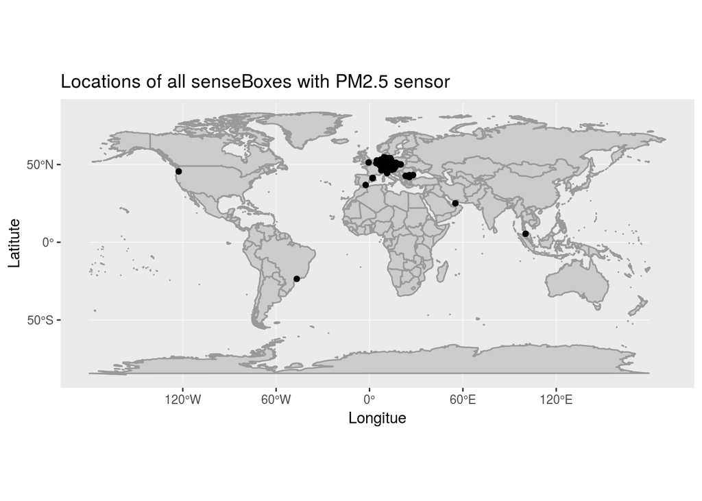

### Particulates at New Year’s Eve in Münster

*How many senseBoxes in Münster measure PM2.5?*

```
## Simple feature collection with 18 features and 2 fields
## geometry type:  POINT
## dimension:      XY
## bbox:           xmin: 7.586553 ymin: 51.903 xmax: 7.684194 ymax: 52.00165
## epsg (SRID):    4326
## proj4string:    +proj=longlat +datum=WGS84 +no_defs
## First 10 features:
##                         X_id                    name
## 1   570bad2b45fd40c8197f13a2     Balkon Gasselstiege
## 2   5750220bed08f9680c6b4154 BalkonBox Mindener Str.
## 3   57585de44bab38000e49fa97       senseBox_wifi_Yun
## 8   58932c89d038b000102f7d35       KiTa Glühwürmchen
## 78  591f578c51d34600116a8ea5     Wetterstation Erpho
## 108 593c20216ccf3b00117ca2d6             stuc_sensor
## 223 599180be7e280a001044b837           C1024_balcony
## 235 599c9b80d67eb500118c6b5e                 wb132ms
## 255 59ad958fd67eb50011b85f6d               Kortumweg
## 273 59c3b5e1d67eb50011335cee         Gruenes_Zentrum
##                      geometry
## 1   POINT (7.607807 51.97458)
## 2   POINT (7.651169 51.95617)
## 3   POINT (7.586553 51.97653)
## 8   POINT (7.614025 52.00165)
## 78  POINT (7.645218 51.96422)
## 108 POINT (7.620859 51.90518)
## 223 POINT (7.684194 51.92934)
## 235 POINT (7.650543 51.95479)
## 255   POINT (7.635283 51.903)
## 273 POINT (7.633289 51.95691)
```

Now we retrieve data for 18 senseBoxes with values in the area of interest.

```r
if (online) {
  class(ms_boxes) <- c("sensebox", class(ms_boxes))
  ms_data <- osem_measurements(ms_boxes, phenomenon = "PM2.5",
                             from = lubridate::as_datetime("2017-12-31 20:00:00"),
                             to = lubridate::as_datetime("2018-01-01 04:00:00"),
                             columns = c("value", "createdAt", "lat", "lon", "boxId",
                                         "boxName", "exposure", "sensorId",
                                         "phenomenon", "unit", "sensorType"))
  # update local data
  data_json <- toJSON(ms_data, digits = NA, pretty = TRUE)
  write(data_json, file = here("data/ms_data.json"))
} else {
  # load data from file and fix column types
  ms_data_file <- fromJSON(here("data/ms_data.json"))
  ms_data <- type_convert(ms_data_file,
                                  col_types = cols(
                                    sensorId = col_factor(levels = NULL),
                                    unit = col_factor(levels = NULL)))
  class(ms_data) <- c(class(ms_data), "sensebox")
}

summary(ms_data %>%
                select(value,sensorId,unit))
```

```
##      value                            sensorId        unit
##  Min.   :  0.60   59458624a4ad590011186665: 815   µg/m^3:  48
##  1st Qu.:  3.80   5a0d58d69fd3c2001129024f: 481   µg/m³ :6907
##  Median :  6.00   5a0c15289fd3c200110f3d34: 480
##  Mean   : 18.94   5a0c30489fd3c20011115fb8: 480
##  3rd Qu.: 11.30   5a0c347b9fd3c2001111b702: 480
##  Max.   :999.90   5a30ea5375a96c000f012fe1: 480
##                   (Other)                 :3739
```

We can now plot 6955 measurements.

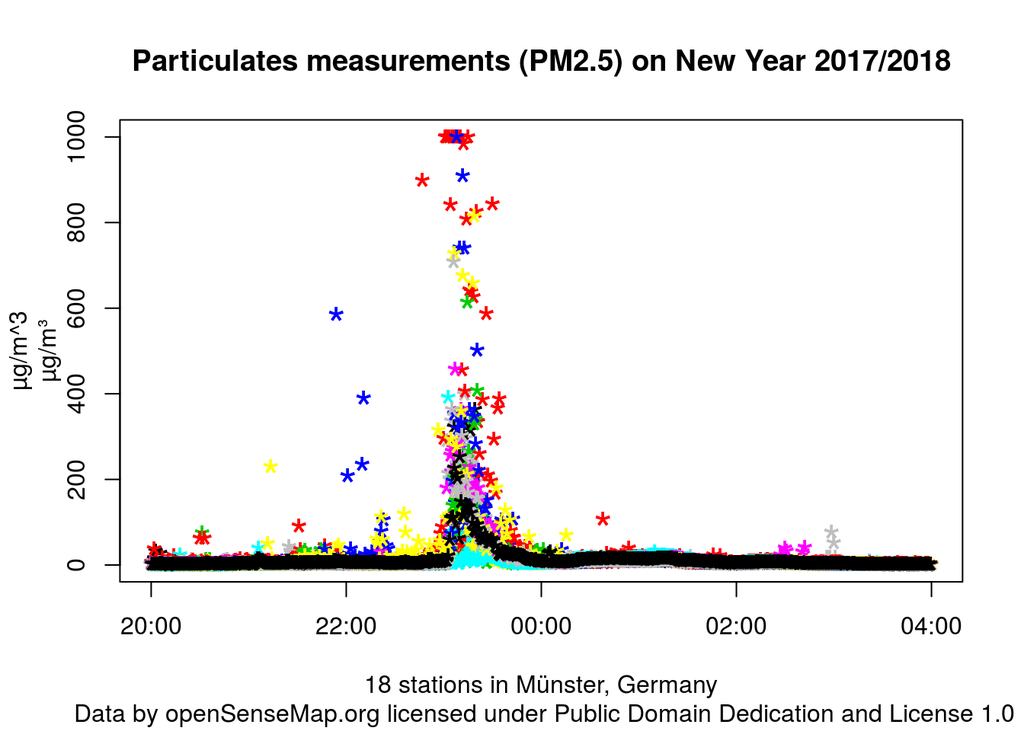

You can see, it was a [very “particular” celebration](http://www.dw.com/en/new-years-eve-are-fireworks-harming-the-environment/a-41957523).

*Who are the record holders?*

Top 3 boxes

[output not shown]

**Note:** The timestamp is UTC and the local time is CET (`UTC+1:00`). The value `999.9` is the maximum value measured by the used sensor [SDS011](https://nettigo.pl/attachments/398).

| Top sensor identifier | Top box name |
| --- | --- |
| 5a0c15289fd3c200110f3d34 | Wetterstation Hansaring |
| 5a0c30489fd3c20011115fb8 | Nordschänke |

Congratulations (?) to boxes for holding the record values just after the new year started.

**Where are the record holding boxes?**

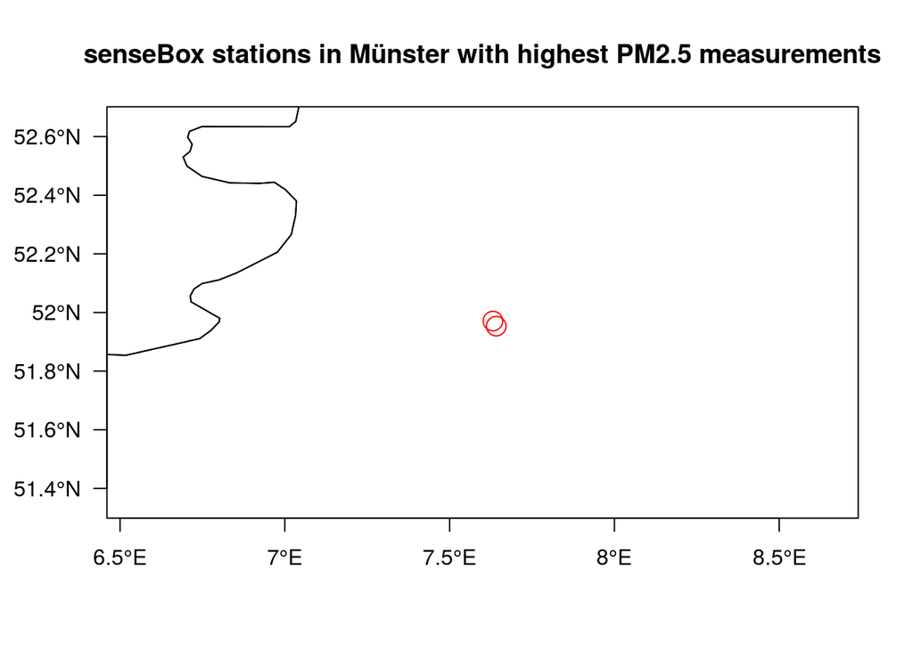

## Conclusion

The presented solution might seem complex. But it caters to many different levels of expertise (one-click open in browser vs. self-building of images and local inspection) and has several fail-safes (binder may disappear, GitHub repository may be lost, Docker may stop working). The additional work is much outweighed by the advantages in transparency and openness.

## License

This document is licensed under a [Creative Commons Attribution 4.0 International](https://creativecommons.org/licenses/by/4.0/) (CC BY 4.0).

## Metadata

```
##  setting  value
##  version  R version 3.4.4 (2018-03-15)
##  system   x86_64, linux-gnu
##  ui       X11
##  language en
##  collate  en_US.UTF-8
##  tz       Europe/Berlin
##  date     2018-08-27
```

```
## Packages -----------------------------------------------------------------
```

```
##  package      * version date       source
##  assertthat     0.2.0   2017-04-11 CRAN (R 3.4.0)
##  backports      1.1.2   2017-12-13 CRAN (R 3.4.3)
##  base         * 3.4.4   2018-03-16 local
##  bindr          0.1.1   2018-03-13 CRAN (R 3.4.4)
##  bindrcpp     * 0.2.2   2018-03-29 CRAN (R 3.4.4)
##  class          7.3-14  2015-08-30 CRAN (R 3.4.0)
##  classInt       0.2-3   2018-04-16 CRAN (R 3.4.4)
##  colorspace     1.3-2   2016-12-14 cran (@1.3-2)
##  compiler       3.4.4   2018-03-16 local
##  crayon         1.3.4   2017-09-16 CRAN (R 3.4.1)
##  datasets     * 3.4.4   2018-03-16 local
##  DBI            1.0.0   2018-05-02 CRAN (R 3.4.4)
##  devtools       1.13.6  2018-06-27 CRAN (R 3.4.4)
##  digest         0.6.15  2018-01-28 CRAN (R 3.4.3)
##  dplyr        * 0.7.6   2018-06-29 CRAN (R 3.4.4)
##  e1071          1.7-0   2018-07-28 CRAN (R 3.4.4)
##  evaluate       0.11    2018-07-17 CRAN (R 3.4.4)
##  foreign        0.8-71  2018-07-20 CRAN (R 3.4.4)
##  ggplot2      * 3.0.0   2018-07-03 CRAN (R 3.4.4)
##  glue           1.3.0   2018-07-17 CRAN (R 3.4.4)
##  graphics     * 3.4.4   2018-03-16 local
##  grDevices    * 3.4.4   2018-03-16 local
##  grid           3.4.4   2018-03-16 local
##  gtable         0.2.0   2016-02-26 CRAN (R 3.4.0)
##  here         * 0.1     2017-05-28 CRAN (R 3.4.4)
##  highr          0.7     2018-06-09 CRAN (R 3.4.4)
##  hms            0.4.2   2018-03-10 CRAN (R 3.4.3)
##  htmltools      0.3.6   2017-04-28 CRAN (R 3.4.0)
##  jsonlite     * 1.5     2017-06-01 cran (@1.5)
##  knitr          1.20    2018-02-20 CRAN (R 3.4.3)
##  lattice        0.20-35 2017-03-25 CRAN (R 3.3.3)
##  lazyeval       0.2.1   2017-10-29 CRAN (R 3.4.2)
##  lubridate    * 1.7.4   2018-04-11 CRAN (R 3.4.4)
##  lwgeom       * 0.1-4   2018-01-28 CRAN (R 3.4.3)
##  magrittr       1.5     2014-11-22 CRAN (R 3.4.0)
##  maps         * 3.3.0   2018-04-03 CRAN (R 3.4.4)
##  maptools     * 0.9-3   2018-07-31 CRAN (R 3.4.4)
##  memoise        1.1.0   2017-04-21 CRAN (R 3.4.3)
##  methods      * 3.4.4   2018-03-16 local
```

[output cut: 13 more lines]

```
##  rprojroot      1.3-2   2018-01-03 CRAN (R 3.4.3)
##  scales         1.0.0   2018-08-09 CRAN (R 3.4.4)
##  sf           * 0.6-3   2018-05-17 CRAN (R 3.4.4)
##  sp           * 1.3-1   2018-06-05 CRAN (R 3.4.4)
##  spData         0.2.9.3 2018-08-01 CRAN (R 3.4.4)
##  stats        * 3.4.4   2018-03-16 local
##  stringi        1.2.4   2018-07-20 CRAN (R 3.4.4)
##  stringr        1.3.1   2018-05-10 CRAN (R 3.4.4)
##  tibble         1.4.2   2018-01-22 CRAN (R 3.4.3)
##  tidyselect     0.2.4   2018-02-26 CRAN (R 3.4.3)
##  tools          3.4.4   2018-03-16 local
##  units        * 0.6-0   2018-06-09 CRAN (R 3.4.4)
##  utils        * 3.4.4   2018-03-16 local
##  withr          2.1.2   2018-03-15 cran (@2.1.2)
##  yaml           2.2.0   2018-07-25 CRAN (R 3.4.4)
```